## 北京市二手房数据分析

### 数据概览

经过爬取和与处理之后，我们一共得到了28051条有效的北京市二手房房源信息数据。数据集中一共有24个字段，包括：标题、户型、面积、楼层、建造年份、所在小区、行政区、镇、街道、房屋总价、房屋单价、房屋地址、经度、纬度、属性标签、是否近地铁、是否近学校、室的数量、厅的数量。

```
summary(house)
```

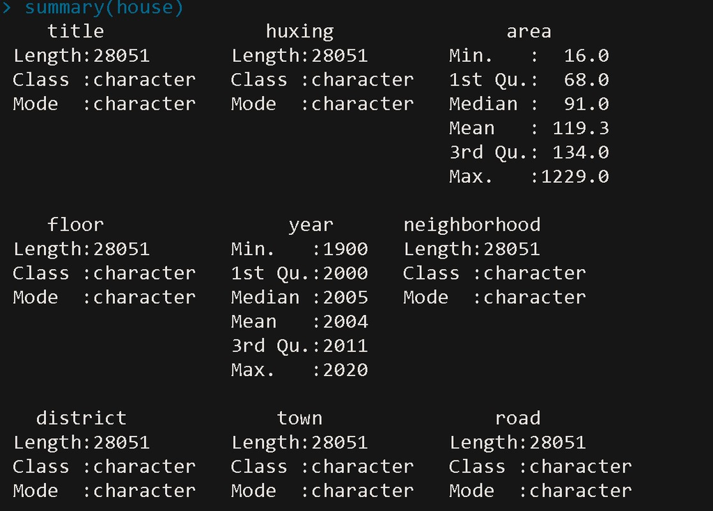

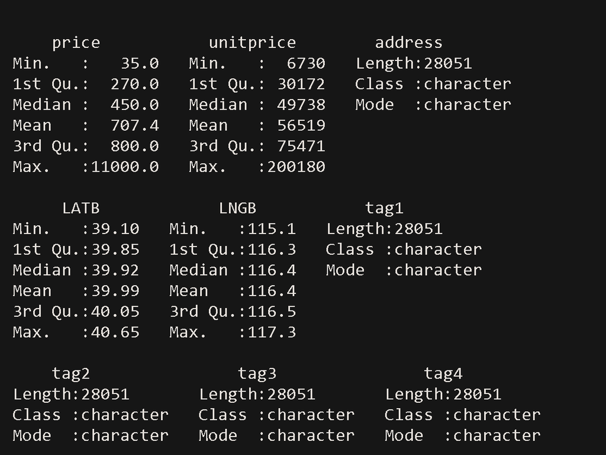

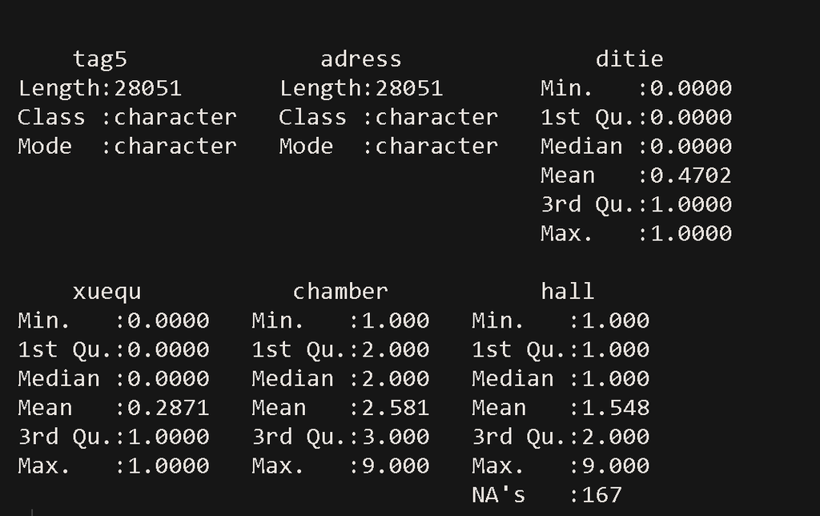

### 描述统计值

```
library(psych)
des<-describe(house$price)
des[2,]<-describe(house$unitprice)
des[3,]<-describe(house$area)
des[4,]<-describe(house$year)
des[5,]<-describe(house$hall)
des[6,]<-describe(house$chamber)
row.names(des)<-c("price","unitprice","area","year","hall","chamber")
show(des)
```

计算非缺失值的数量、平均数、标准差、中位数、截尾均值、绝对中位差、最小值、最大值、值域、偏度、峰度和平均值的标准误。可以看到，不同的指标分布特点各不相同。

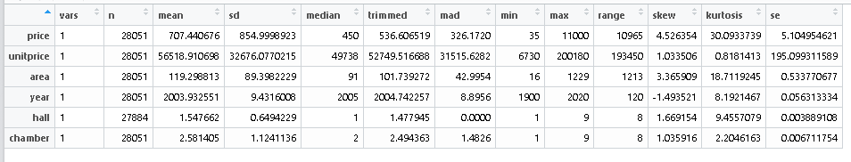

### 房屋价格直方图

```
hist(house$price,
     main="房屋价格直方图：统计间隔尺度为100万",
     xlab="房屋价格（万元）",
     ylab="房屋数量",
     breaks=seq(0,12000,50),
     col=heat.colors(50)
    )
```

[figure not shown]

以50万为间隔尺度绘制房屋价格直方图:

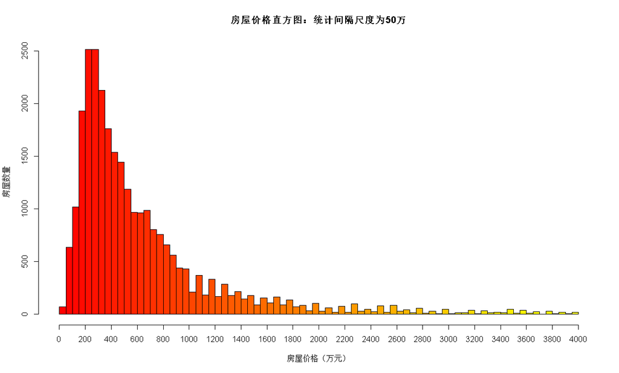

可以看出北京地区二手房房价在0-12000万的区间内呈现一个右偏的尖峰分布，在200-300万价格区间内的房子数量最多。

### 北京市各行政区平均房屋单价及面积

```
library(ggplot2)
library(scales)
ggplot()+
  geom_bar(data,mapping=aes(x=x,y=y,fill=group),stat='identity')+
  ylab("单价（元/平方米）")+
  geom_line(data,mapping=aes(x=x,y=tem,group=1),linetype=5,size=1)+
scale_y_continuous(breaks=seq(0,150000,5000),
                sec.axis=sec_axis(~rescale(.,c(min(data$z),max(data$z))),
                name = "房屋面积(平方米)"))+
  geom_point(data,mapping=aes(x=x,y=tem,group=1),shape=17,size=4)+
  scale_color_manual(values = c('red')) +#自定义颜色
  geom_text(data,mapping=aes(x=x,y=tem-8000,group=1,label=data[1:15,"z"]))
```

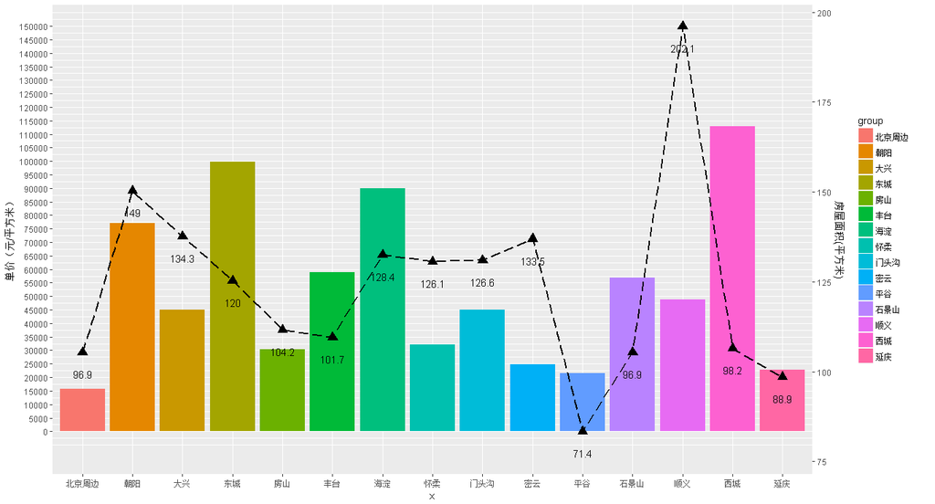

柱形图表示每个区的平均房屋单价，折线图表示房屋平均面积，可以看出不同区的房子价格和面积各不相同，北京周边地区以及平谷区房价最低但面积也相对较小。顺义区房屋平均单价不高，平均面积却远远超出了其他区。东城、海淀、西城三个区无论是面积还是价格都比较接近。

### 北京各行政区二手房单价箱线图

```
v<-boxplot(hadian$unitprice,fengtai$unitprice,
        shijingshan$unitprice,chaoyang$unitprice,
        shunyi$unitprice,dongcheng$unitprice,
        names=c('海淀','丰台','石景山','朝阳','顺义',
                 '东城'),
        col=heat.colors(8),
        #border="grey",
        main="北京各行政区二手房单价箱线图",
        ylab="单价（元/平米）",
        pch=20
      )
me1<-data.frame(v$stats[3,])
text(me1-3000,labels=me1[1:6,1])
```

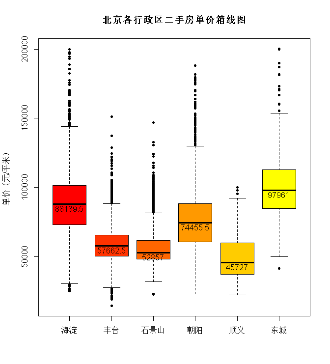

在此我们选取了6个区进行对比分析，可以看出每个区的房屋单价偏态都不明显，但是不同区主要的分布区间各不相同。海淀、东城、朝阳房价相对比较高，而丰台、石景山、顺义房价相对较低。

### 各行政区指标雷达图

```
#绘制雷达图
radargig<-meanhouse[2:6,]
row.names(radargig)<-radargig[,1]
radargig<-radargig[,-(8:9)]
radargig<-radargig[,-(6:7)]
Name<-radargig[,1]
radargig<-radargig[,-(1)]
#数据标准化
zradargig<-radargig
for(i in 1:length(radargig))
{
  zradargig[,i]<-(radargig[,i]-min(radargig[,i]))/(max(radargig[,i])-min(radargig[,i]))
}
zradargig<-data.frame(Name,zradargig)

library(knitr)
library(ggradar)
ggradar(zradargig,axis.label.size =8,grid.label.size = 18)
```

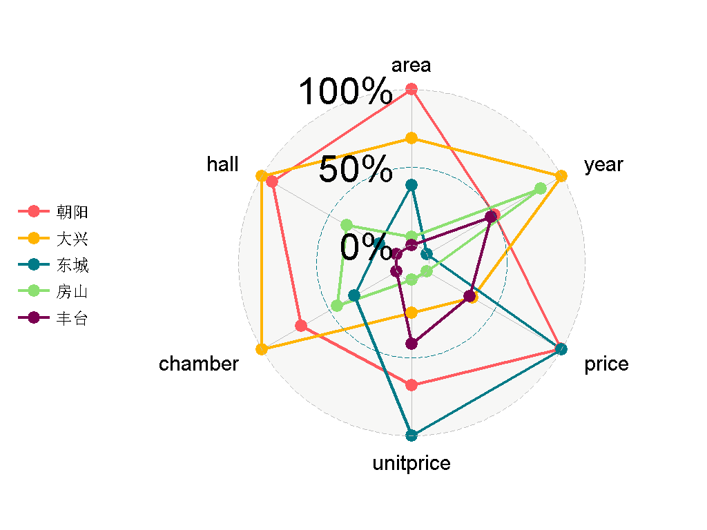

针对图中五个区的平均面积、建造年份、价格、单价、室数、厅数绘制雷达图，可以看到每个区的差别很大。丰台区和房山区有几个指标非常小。在丰台的房子面积小，房间数目也少。在房山，房子价格低，面积也相对较小。而朝阳区的大房子比较多，价格也比较贵。大兴区和房山区新建的房子比较多，而东城区基本上都是老房子。

### 回归分析

使用R中的lm函数进行多元回归建模。

```
options(scipen=100000)
data<-data.frame(unitprice=house$unitprice,area=house$area,house$year,house$ditie,house$xuequ,house$chamber,house$hall)
sol.lm<-lm(formula=unitprice~.,data=data)
summary(sol.lm)
```

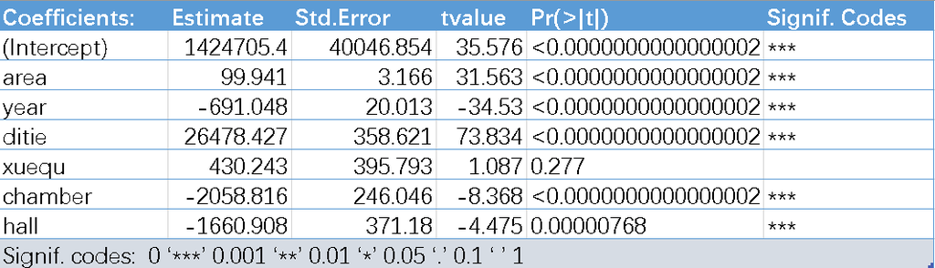

可以看出面积、是否近地铁与单价正相关，而建造时间、室数、厅数与房屋单价呈现负相关关系，是否为学区房与房屋单价的相关性不大。

使用模型可以对房屋价格进行预测,选取前200条数据进行预测如下：

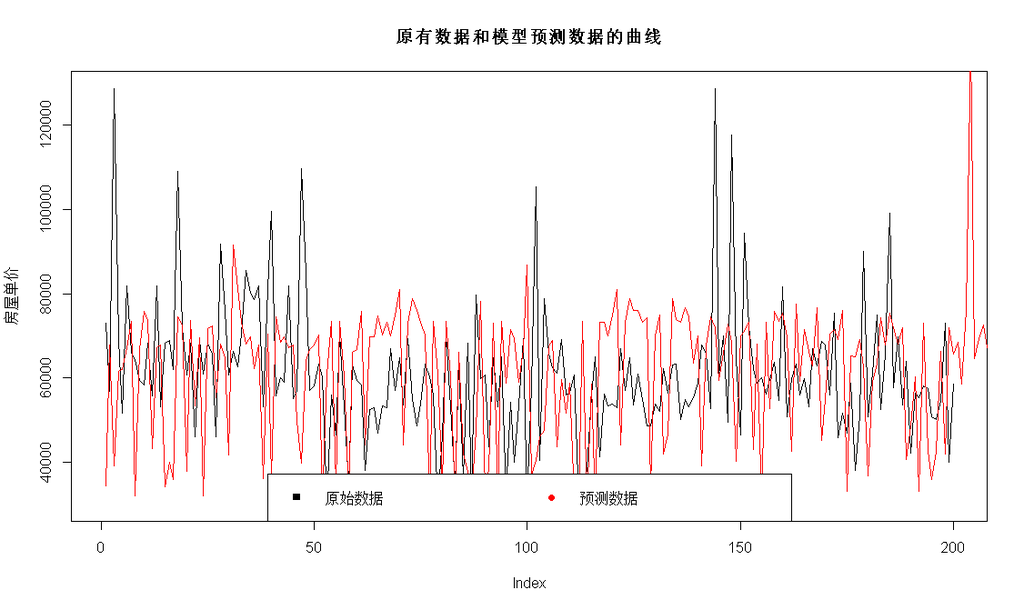